# Insights

1.主人对狗狗评分的平均数为11.65，但由于有较大的异常值（如1776），所以参考平均数不够准确。

2.评分的中位数为11，上下四分位数分别为10和12，说明主人给狗狗的评分大部分都超过了十分制的满分，主人对自己的狗狗普遍评价很高。

```python
twitter_archive_master.describe()
```

|  | tweet_id | rating_numerator | rating_denominator | favorite_count | retweet_count | p1_conf | p2_conf | p3_conf |
| --- | --- | --- | --- | --- | --- | --- | --- | --- |
| count | 2.051000e+03 | 2051.000000 | 2051.0 | 2051.000000 | 2051.000000 | 2051.000000 | 2.051000e+03 | 2.051000e+03 |
| mean | 7.383097e+17 | 11.654939 | 10.0 | 8568.668454 | 2887.498781 | 0.594672 | 1.349422e-01 | 6.022921e-02 |
| std | 6.781522e+16 | 40.070827 | 0.0 | 12499.343305 | 4878.868291 | 0.271257 | 1.008930e-01 | 5.082182e-02 |
| min | 6.660209e+17 | 0.000000 | 10.0 | 0.000000 | 13.000000 | 0.044333 | 1.011300e-08 | 1.740170e-10 |
| 25% | 6.762505e+17 | 10.000000 | 10.0 | 1634.000000 | 615.000000 | 0.363683 | 5.388625e-02 | 1.605405e-02 |
| 50% | 7.117438e+17 | 11.000000 | 10.0 | 3815.000000 | 1367.000000 | 0.588230 | 1.187690e-01 | 4.934910e-02 |
| 75% | 7.931732e+17 | 12.000000 | 10.0 | 10836.000000 | 3363.000000 | 0.843855 | 1.963605e-01 | 9.203645e-02 |
| max | 8.924206e+17 | 1776.000000 | 10.0 | 143944.000000 | 77713.000000 | 1.000000 | 4.880140e-01 | 2.710420e-01 |

3.参考p1_conf，对狗的图片的识别置信度平均数为0.59，最高可达到1。 对于图片的识别不是特别准确，存在误判。同时一些图片中的狗较难分辨。

4.点赞数最高的狗狗获得了143944的赞，找到这只狗狗的照片，点赞数最高的狗的照片是：

[figure not shown]

# visualization

由于主人给狗狗的评分存在过高的分数，如1776，666等，所以将超过10分过多的评分视为异常值。 根据评分的上下四分位数（10和12），根据Tukey‘s test方法，令K=3，计算出接受极端异常值的区间上限12+K*(12-10)=18. 所以选择18作为上限，作出评分的直方图。可以看到主人对狗狗的评分主要集中在10到12之间，评分低于10分的情况比较少。

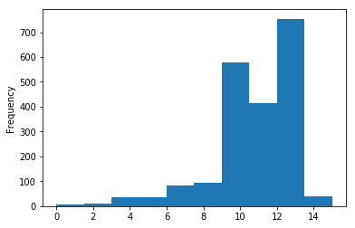

```python
twitter_archive_master[twitter_archive_master.rating_numerator<18]['rating_numerator'].plot(kind='hist')
```